# prompt

### Required Assignment 5.1: Will the Customer Accept the Coupon?

**Context**

Imagine driving through town and a coupon is delivered to your cell phone for a restaurant near where you are driving. Would you accept that coupon and take a short detour to the restaurant? Would you accept the coupon but use it on a subsequent trip? Would you ignore the coupon entirely? What if the coupon was for a bar instead of a restaurant? What about a coffee house? Would you accept a bar coupon with a minor passenger in the car? What about if it was just you and your partner in the car? Would weather impact the rate of acceptance? What about the time of day?

Obviously, proximity to the business is a factor on whether the coupon is delivered to the driver or not, but what are the factors that determine whether a driver accepts the coupon once it is delivered to them? How would you determine whether a driver is likely to accept a coupon?

**Overview**

The goal of this project is to use what you know about visualizations and probability distributions to distinguish between customers who accepted a driving coupon versus those that did not.

**Data**

This data comes to us from the UCI Machine Learning repository and was collected via a survey on Amazon Mechanical Turk. The survey describes different driving scenarios including the destination, current time, weather, passenger, etc., and then ask the person whether he will accept the coupon if he is the driver. Answers that the user will drive there ‘right away’ or ‘later before the coupon expires’ are labeled as ‘Y = 1’ and answers ‘no, I do not want the coupon’ are labeled as ‘Y = 0’. There are five different types of coupons -- less expensive restaurants (under $20), coffee houses, carry out & take away, bar, and more expensive restaurants ($20 - $50).

**Deliverables**

Your final product should be a brief report that highlights the differences between customers who did and did not accept the coupons. To explore the data you will utilize your knowledge of plotting, statistical summaries, and visualization using Python. You will publish your findings in a public facing github repository as your first portfolio piece.

### Data Description

Keep in mind that these values mentioned below are average values.

The attributes of this data set include:

1. User attributes
   - Gender: male, female
   - Age: below 21, 21 to 25, 26 to 30, etc.
   - Marital Status: single, married partner, unmarried partner, or widowed
   - Number of children: 0, 1, or more than 1
   - Education: high school, bachelors degree, associates degree, or graduate degree
   - Occupation: architecture & engineering, business & financial, etc.
   - Annual income: less than \$12500, \$12500 - \$24999, \$25000 - \$37499, etc.
   - Number of times that he/she goes to a bar: 0, less than 1, 1 to 3, 4 to 8 or greater than 8
   - Number of times that he/she buys takeaway food: 0, less than 1, 1 to 3, 4 to 8 or greater

   than 8
   - Number of times that he/she goes to a coffee house: 0, less than 1, 1 to 3, 4 to 8 or

   greater than 8
   - Number of times that he/she eats at a restaurant with average expense less than \$20 per

   person: 0, less than 1, 1 to 3, 4 to 8 or greater than 8
   - Number of times that he/she goes to a bar: 0, less than 1, 1 to 3, 4 to 8 or greater than 8
2. Contextual attributes
   - Driving destination: home, work, or no urgent destination
   - Location of user, coupon and destination: we provide a map to show the geographical

   location of the user, destination, and the venue, and we mark the distance between each two places with time of driving. The user can see whether the venue is in the same direction as the destination.
   - Weather: sunny, rainy, or snowy
   - Temperature: 30F, 55F, or 80F
   - Time: 10AM, 2PM, or 6PM
   - Passenger: alone, partner, kid(s), or friend(s)
3. Coupon attributes
   - time before it expires: 2 hours or one day

```python
import matplotlib.pyplot as plt
import seaborn as sns
import pandas as pd
import numpy as np
```

### Problems

Use the prompts below to get started with your data analysis.

1. Read in the `coupons.csv` file.

```python
data = pd.read_csv('data/coupons.csv')
```

```python
data.head()
```

|  | destination | passanger | weather | temperature | time | coupon | expiration | gender | age | maritalStatus | ... | CoffeeHouse | CarryAway | RestaurantLessThan20 | Restaurant20To50 | toCoupon_GEQ5min | toCoupon_GEQ15min | toCoupon_GEQ25min | direction_same | direction_opp | Y |
| --- | --- | --- | --- | --- | --- | --- | --- | --- | --- | --- | --- | --- | --- | --- | --- | --- | --- | --- | --- | --- | --- |
| 0 | No Urgent Place | Alone | Sunny | 55 | 2PM | Restaurant(<20) | 1d | Female | 21 | Unmarried partner | ... | never | NaN | 4~8 | 1~3 | 1 | 0 | 0 | 0 | 1 | 1 |
| 1 | No Urgent Place | Friend(s) | Sunny | 80 | 10AM | Coffee House | 2h | Female | 21 | Unmarried partner | ... | never | NaN | 4~8 | 1~3 | 1 | 0 | 0 | 0 | 1 | 0 |
| 2 | No Urgent Place | Friend(s) | Sunny | 80 | 10AM | Carry out & Take away | 2h | Female | 21 | Unmarried partner | ... | never | NaN | 4~8 | 1~3 | 1 | 1 | 0 | 0 | 1 | 1 |
| 3 | No Urgent Place | Friend(s) | Sunny | 80 | 2PM | Coffee House | 2h | Female | 21 | Unmarried partner | ... | never | NaN | 4~8 | 1~3 | 1 | 1 | 0 | 0 | 1 | 0 |
| 4 | No Urgent Place | Friend(s) | Sunny | 80 | 2PM | Coffee House | 1d | Female | 21 | Unmarried partner | ... | never | NaN | 4~8 | 1~3 | 1 | 1 | 0 | 0 | 1 | 0 |

5 rows × 26 columns

2. Investigate the dataset for missing or problematic data.

```python
missing_data = data.isnull().sum()
print(missing_data)
data.shape
```

```
destination                 0
passanger                   0
weather                     0
temperature                 0
time                        0
coupon                      0
expiration                  0
gender                      0
age                         0
maritalStatus               0
has_children                0
education                   0
occupation                  0
income                      0
car                     12576
Bar                       107
CoffeeHouse               217
CarryAway                 151
RestaurantLessThan20      130
Restaurant20To50          189
toCoupon_GEQ5min            0
toCoupon_GEQ15min           0
toCoupon_GEQ25min           0
direction_same              0
direction_opp               0
Y                           0
dtype: int64
```

```
(12684, 26)
```

3. Decide what to do about your missing data -- drop, replace, other...

```python
'''
car                     12576, does not matter. do nothing
Bar                       107 , missing data convert to "never" , data['Bar'].value_counts()
CoffeeHouse               217 , missing data convert to "never"   Number of times that he/she goes to a coffee house: 0, less than 1, 1 to 3, 4 to 8 or greater than 8,
CarryAway                 151, missing data convert to "never"
RestaurantLessThan20      130, missing data convert to "never"
Restaurant20To50          189, missing data convert to "never"
'''
#data.sample()
#data['Restaurant20To50'].value_counts()
##data_filled = df.fillna('never')
data_filled=data.copy()
data_filled[['Bar', 'CoffeeHouse','CarryAway','RestaurantLessThan20','Restaurant20To50']] = data_filled[['Bar', 'CoffeeHouse','CarryAway','RestaurantLessThan20','Restaurant20To50']].fillna('never')
data_filled.sample(5)
#missing_data2 = data_filled.isnull().sum()
#print(missing_data2)
```

|  | destination | passanger | weather | temperature | time | coupon | expiration | gender | age | maritalStatus | ... | CoffeeHouse | CarryAway | RestaurantLessThan20 | Restaurant20To50 | toCoupon_GEQ5min | toCoupon_GEQ15min | toCoupon_GEQ25min | direction_same | direction_opp | Y |
| --- | --- | --- | --- | --- | --- | --- | --- | --- | --- | --- | --- | --- | --- | --- | --- | --- | --- | --- | --- | --- | --- |
| 4929 | Home | Alone | Sunny | 80 | 6PM | Coffee House | 1d | Female | 21 | Unmarried partner | ... | never | less1 | 1~3 | never | 1 | 0 | 0 | 1 | 0 | 0 |
| 6722 | Home | Kid(s) | Sunny | 55 | 6PM | Restaurant(20-50) | 1d | Female | 31 | Married partner | ... | 1~3 | 1~3 | 1~3 | 1~3 | 1 | 1 | 1 | 0 | 1 | 0 |
| 1703 | No Urgent Place | Friend(s) | Sunny | 80 | 2PM | Coffee House | 1d | Female | 26 | Married partner | ... | less1 | 1~3 | 1~3 | never | 1 | 1 | 0 | 0 | 1 | 1 |
| 9026 | No Urgent Place | Friend(s) | Sunny | 30 | 10PM | Carry out & Take away | 1d | Male | 21 | Single | ... | less1 | 4~8 | less1 | never | 1 | 1 | 0 | 0 | 1 | 1 |
| 4869 | Work | Alone | Sunny | 80 | 7AM | Restaurant(20-50) | 2h | Male | below21 | Single | ... | 1~3 | 4~8 | 1~3 | less1 | 1 | 1 | 0 | 0 | 1 | 0 |

5 rows × 26 columns

4. What proportion of the total observations chose to accept the coupon?

```
Percentage of acceptance of the coupon: 0.57
```

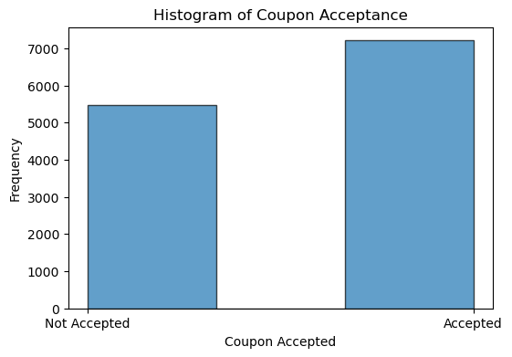

```python
# Calculate the proportion of observations that chose to accept the coupon
acceptance_percent = data_filled['Y'].mean()

print(f"Percentage of acceptance of the coupon: {acceptance_percent:.2f}")

# Plot the histogram
plt.figure(figsize=(6, 4))
plt.hist(data_filled['Y'], bins=3, edgecolor='black', alpha=0.7)

# Adding labels and title
plt.xlabel('Coupon Accepted')
plt.ylabel('Frequency')
plt.title('Histogram of Coupon Acceptance')

# Show the plot
plt.xticks([0, 1], ['Not Accepted', 'Accepted'])
## the savefig must be placed before the show()
plt.savefig('data/coupon_acceptance_histogram.png', format='png', dpi=600)
plt.show()
```

5. Use a bar plot to visualize the `coupon` column.

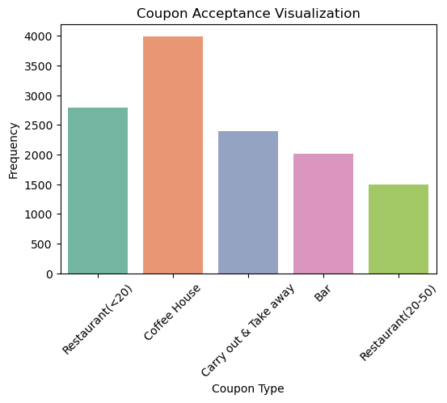

```python
# Create a bar plot to visualize the 'coupon' column
plt.figure(figsize=(6, 4))
sns.countplot(x='coupon', data=data_filled, palette='Set2', hue='coupon')

# Adding labels and title
plt.xlabel('Coupon Type')
plt.xticks(rotation=45)
plt.ylabel('Frequency')
plt.title('Coupon Acceptance Visualization')

# Show the plot

plt.savefig('data/coupon_hist.png', format='png', dpi=600)
plt.show()
```

6. Use a histogram to visualize the temperature column.

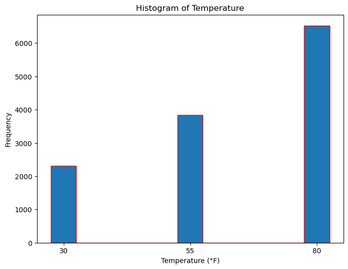

```
temperature
80    6528
55    3840
30    2316
Name: count, dtype: int64
```

```python
# Plotting the histogram using seaborn
plt.figure(figsize=(8, 6))
#sns.histplot(data_filled['temperature'], kde=True, bins=12, color='blue', alpha=0.7)
bins=range(min(data_filled['temperature']), max(data_filled['temperature']) + 6, 5)
plt.hist(data_filled['temperature'], bins=bins, edgecolor='red',align='left')  # Increase bins


# Adding labels and title
plt.xlabel('Temperature (°F)')
plt.ylabel('Frequency')
plt.title('Histogram of Temperature')
# Set x-axis ticks with increments of 25
plt.xticks(range(min(data_filled['temperature']), max(data_filled['temperature'])+5, 25))

# Show the plot
plt.savefig('data/temperature_hist.png', format='png', dpi=600)
plt.show()

data_filled['temperature'].value_counts()
#print(bins)
```

```python
list(range(30, 86,5))
```

```
[30, 35, 40, 45, 50, 55, 60, 65, 70, 75, 80, 85]
```

```python
data.info()
```

```
<class 'pandas.core.frame.DataFrame'>
RangeIndex: 12684 entries, 0 to 12683
Data columns (total 26 columns):
 #   Column                Non-Null Count  Dtype
---  ------                --------------  -----
 0   destination           12684 non-null  object
 1   passanger             12684 non-null  object
 2   weather               12684 non-null  object
 3   temperature           12684 non-null  int64
 4   time                  12684 non-null  object
 5   coupon                12684 non-null  object
 6   expiration            12684 non-null  object
 7   gender                12684 non-null  object
 8   age                   12684 non-null  object
 9   maritalStatus         12684 non-null  object
```

[output cut: 18 more lines]

**Investigating the Bar Coupons**

Now, we will lead you through an exploration of just the bar related coupons.

1. Create a new `DataFrame` that contains just the bar coupons.

```python
data_bar=data_filled.query('coupon=="Bar"')
#data_bar.shape
data_bar.sample(5)
```

|  | destination | passanger | weather | temperature | time | coupon | expiration | gender | age | maritalStatus | ... | CoffeeHouse | CarryAway | RestaurantLessThan20 | Restaurant20To50 | toCoupon_GEQ5min | toCoupon_GEQ15min | toCoupon_GEQ25min | direction_same | direction_opp | Y |
| --- | --- | --- | --- | --- | --- | --- | --- | --- | --- | --- | --- | --- | --- | --- | --- | --- | --- | --- | --- | --- | --- |
| 8702 | No Urgent Place | Partner | Sunny | 30 | 10AM | Bar | 1d | Male | 31 | Married partner | ... | 4~8 | less1 | 4~8 | less1 | 1 | 1 | 0 | 0 | 1 | 0 |
| 10951 | No Urgent Place | Friend(s) | Sunny | 80 | 10PM | Bar | 1d | Female | 31 | Married partner | ... | less1 | gt8 | 4~8 | less1 | 1 | 1 | 0 | 0 | 1 | 0 |
| 12067 | No Urgent Place | Friend(s) | Sunny | 80 | 10PM | Bar | 1d | Female | 46 | Married partner | ... | 4~8 | 4~8 | 1~3 | never | 1 | 1 | 0 | 0 | 1 | 0 |
| 7005 | No Urgent Place | Friend(s) | Rainy | 55 | 10PM | Bar | 2h | Female | 31 | Married partner | ... | 1~3 | less1 | 1~3 | 1~3 | 1 | 1 | 0 | 0 | 1 | 0 |
| 12175 | No Urgent Place | Friend(s) | Sunny | 55 | 10PM | Bar | 2h | Male | 26 | Single | ... | gt8 | gt8 | gt8 | gt8 | 1 | 1 | 0 | 0 | 1 | 0 |

5 rows × 26 columns

2. What proportion of bar coupons were accepted?

```
Percentage of acceptance of the coupon: 0.41
```

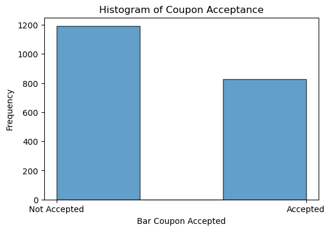

```python
# Calculate the proportion of observations that chose to accept the bar coupon
acceptance_percent = data_bar['Y'].mean()

print(f"Percentage of acceptance of the coupon: {acceptance_percent:.2f}")

# Plot the histogram
plt.figure(figsize=(6, 4))
plt.hist(data_bar['Y'], bins=3, edgecolor='black', alpha=0.7)

# Adding labels and title
plt.xlabel('Bar Coupon Accepted')
plt.ylabel('Frequency')
plt.title('Histogram of Coupon Acceptance')

# Show the plot
plt.xticks([0, 1], ['Not Accepted', 'Accepted'])
## the savefig must be placed before the show()
plt.savefig('data/Bar_coupon_acceptance_histogram.png', format='png', dpi=600)
plt.show()
```

3. Compare the acceptance rate between those who went to a bar 3 or fewer times a month to those who went more.

```
Percentage of bar acceptance for people who went to a bar 3 or fewer a month: 0.37
Percentage of acceptance people who went to a bar more than 3 a month: 0.77
```

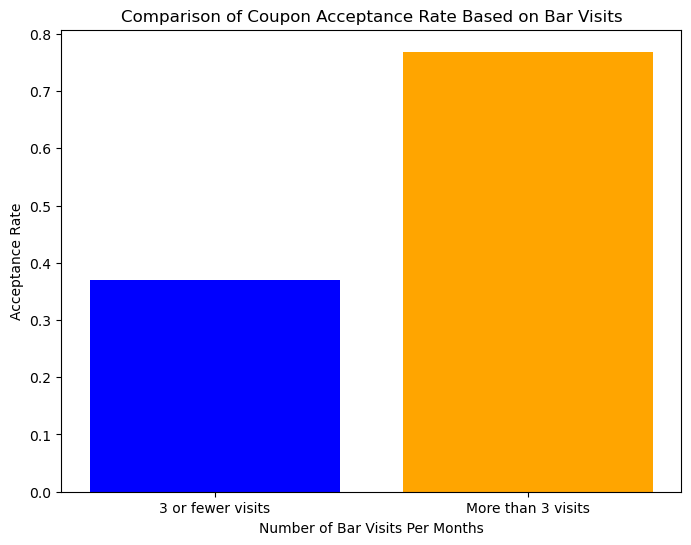

```python
data_bar[data_bar['Bar'].isin ( ['never','less1','1~3'])]
Bar_acceptance_3less = data_bar[data_bar['Bar'].isin ( ['never','less1','1~3'])]['Y'].mean()
Bar_acceptance_3more = data_bar[data_bar['Bar'].isin ( ['4~8','gt8'])]['Y'].mean()

print(f"Percentage of bar acceptance for people who went to a bar 3 or fewer a month: {Bar_acceptance_3less:.2f}")
print(f"Percentage of acceptance people who went to a bar more than 3 a month: {Bar_acceptance_3more:.2f}")

# Create a bar plot to visualize the acceptance rates
plt.figure(figsize=(8, 6))
plt.bar(['3 or fewer visits', 'More than 3 visits'], [Bar_acceptance_3less, Bar_acceptance_3more], color=['blue', 'orange'])

# Add labels and title
plt.xlabel('Number of Bar Visits Per Months')
plt.ylabel('Acceptance Rate')
plt.title('Comparison of Coupon Acceptance Rate Based on Bar Visits')

# Show the plot
plt.savefig('data/Bar_coupon_acceptance_rate.png', format='png', dpi=600)
plt.show()
```

4. Compare the acceptance rate between drivers who go to a bar more than once a month and are over the age of 25 to the all others. Is there a difference?

```
Percentage of bar acceptance for all (2017 person): 0.41
Percentage of bar acceptance for 1more and 25+ years (420 person): 0.70
Percentage of bar acceptance for others (1597 person):: 0.34
```

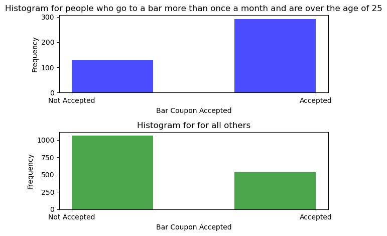

```python
data_filled['age']=data_filled['age'].replace({'50plus': '50', 'below21': '21'})
#data_filled['age'] = pd.to_numeric(data_filled['age'], errors='coerce')
data_filled['age'] = data_filled['age'].astype(int)

data_bar=data_filled.query('coupon=="Bar"')

Bar_acceptance_overall = data_bar['Y'].mean()
Bar_frequency=['1~3','4~8','gt8']
person_count_bar_all=data_bar.shape[0]
person_count_1more_over25=data_bar.query('(Bar in @Bar_frequency) and (age > 25)').shape[0]
person_count_other=data_bar.query('(Bar not in @Bar_frequency) or (age <= 25)').shape[0]
Bar_acceptance_1more_over25 = data_bar.query('(Bar in @Bar_frequency) and (age > 25)')['Y'].mean()
Bar_acceptance_others = data_bar.query('(Bar not in @Bar_frequency) | (age <= 25)')['Y'].mean()

print(f"Percentage of bar acceptance for all ({person_count_bar_all} person): {Bar_acceptance_overall:.2f}")
print(f"Percentage of bar acceptance for 1more and 25+ years ({person_count_1more_over25} person): {Bar_acceptance_1more_over25:.2f}")
print(f"Percentage of bar acceptance for others ({person_count_other} person):: {Bar_acceptance_others:.2f}")

# Plot for Condition 1
plt.subplot(2, 1, 1)
plt.hist(data_bar.query('(Bar in @Bar_frequency) and (age > 25)')['Y'], bins=3, color='blue', alpha=0.7)
plt.title('Histogram for people who go to a bar more than once a month and are over the age of 25')
plt.xlabel('Bar Coupon Accepted')
plt.ylabel('Frequency')
plt.xticks([0, 1], ['Not Accepted', 'Accepted'])

# Plot for Condition 2
plt.subplot(2, 1, 2)
plt.hist(data_bar.query('(Bar not in @Bar_frequency) | (age <= 25)')['Y'], bins=3, color='green', alpha=0.7)
plt.title('Histogram for for all others')
plt.xlabel('Bar Coupon Accepted')
plt.ylabel('Frequency')
plt.xticks([0, 1], ['Not Accepted', 'Accepted'])

# Adjust layout
plt.tight_layout()
plt.show()


#data_bar['age'].value_counts()
#data_bar['Bar'].value_counts()
#data_bar.info()
```

5. Use the same process to compare the acceptance rate between drivers who go to bars more than once a month and had passengers that were not a kid and had occupations other than farming, fishing, or forestry.